```
toc: yes
toc_float:
  collapsed: true
```

## Introduction

### About Me

To quote Nate Bargatze, “Hello World!”

As you can see above, my name is Kevin Schell. I am a practicing physical therapist with over fourteen years of clinical experience working with adults admitted to a major academic medical center in Boston. I am a board-certified clinical specialist in geriatric physical therapy and have provided physical therapy care to adults across all specialties including critical care environments and the hospital’s emergency department. In fact, my time working in the emergency department ignited a new passion for me to take my clinical experience and (hopefully) positively impact the patient experience at a different level from one-on-one patient care. To this end, I completed my [Master of Science in Healthcare Data Analytics at the MGH Institute of Health Professions](https://www.mghihp.edu/healthcare-leadership/degrees-programs/ms-healthcare-data-analytics). I currently work as a healthcare data analyst.

To supplement my learning and growth, I have used different publicly available datasets to practice visualization techniques while looking for potential associations to further investigate with statistical analyses. Most recently, I utilized [Employee Attrition from Healthcare](https://www.kaggle.com/datasets/jpmiller/employee-attrition-for-healthcare) from Kaggle (Miller, 2023). In particular, I worked through logistic regression modeling to identify independent risk factors associated with healthcare works leaving their jobs. I completed these efforts using R (R Core Team, 2024) via R Studio for Windows version 2024.4.1.748 (Posit Team, 2024). Please see my acknowledgements and citations for all packages utilized for this analysis.

Please feel free to peruse the rest of this site to see my efforts related to this project.

### Dataset

The Employee Attrition from Healthcare dataset includes fabricated data. Overall, there are nearly 1,700 observations with 34 variables with near flawless data capture (i.e. minimal missing values and no duplicate observations). The primary outcome of interest for this analysis involves whether or not an individual left their job, captured in the variable Attrition. The potential independent variables include demographic information, work experiences, and quality of life measures. The author of the dataset referenced the US healthcare system. Given this, I am making some assumptions regarding units of measure. For example, I am assuming DistanceFromHome is captured in miles as opposed to kilometers, and compensation values are reported in US Dollars. I am also assuming that the self report measures follow typical 4-point Likert scales, however, this is never explicitly stated.

### Addressing Variable Type and Levels

Several of the variables were interpreted as the wrong variable type after being read into R. For example, the main outcome of interest for this dataset Attrition was initially treated as a character/string variable. I converted this to a factor. This was a recurring issue across several variables. To reduce the volume of coding required, I converted the string/character variables to factor variables and then later updated ordinal variables with their respective levels respectively.

I also relabeled the JobRole level Admin to Administrative. This Admin level presented a bit of an issue as it is unclear whether it reflects a truly different level from Administrative versus represents an issue in how the information was collected (i.e. free text submission). I could have simply removed the limited number of observations with JobRole == Admin, but I decided to treat Admin as representing the same role group as Administrative.

```r
if (!require(tidyverse)) install.packages("tidyverse")
library(tidyverse)
if (!require(gt)) install.packages("gt")
library(gt)
if (!require(gtsummary)) install.packages("gtsummary")
library(gtsummary)
setwd("C:\\Users\\kjsch\\Documents\\Schell Data Analytics Portfolio\\Spring 2024 Data Analytics Project")
att <- read.csv("watson_healthcare_modified.csv")
att$Attrition<-as.factor(att$Attrition)
att <- att %>%
  mutate(across(where(is.character), as.factor))
att$JobRole<-recode_factor(att$JobRole, "Admin" = "Administrative")
att$EnvironmentSatisfaction<-factor(att$EnvironmentSatisfaction, ordered  = TRUE, levels = c("1", "2", "3", "4"))
att$JobLevel<-factor(att$JobLevel, ordered  = TRUE, levels = c("1", "2", "3", "4"))
att$JobInvolvement<-factor(att$JobInvolvement, ordered = TRUE, levels = c("1", "2", "3", "4"))
att$JobSatisfaction<-factor(att$JobSatisfaction, ordered = TRUE, levels = c("1", "2", "3", "4"))
att$RelationshipSatisfaction<-factor(att$RelationshipSatisfaction, ordered = TRUE, level = c("1", "2", "3", "4"))
att$PerformanceRating<-factor(att$PerformanceRating, ordered = TRUE, levels = c("1", "2", "3", "4"))
att$BusinessTravel<-factor(att$BusinessTravel, ordered = TRUE, levels = c("Non-Travel", "Travel_Rarely", "Travel_Frequently"))
att$WorkLifeBalance<-factor(att$WorkLifeBalance, ordered = TRUE, levels = c("1", "2", "3", "4"))
att$Shift<-as.factor(att$Shift)
```

### Addressing Missingness

Out of the 34 variables included in this dataset, only JobLevel contained missing values. There are 81 observations with “NA” as their value for JobLevel. It is possible that “NA” accurately reflects these observations’ JobLevel. In other words, there may be 81 respondents whose roles do not include ascending levels. However, it is also possible that some respondents may have inadvertently failed to respond to this question, or there may have been a transcription error when this dataset was generated from the raw data. Without knowing how this fabricated data was “collected,” it is impossible to know for certain.

Below you will find my initial analysis of missingness using the mice package. The analysis confirmed that only JobLevel had missing values. Summaries of datasets with all observations and one with observations removed for missing JobLevel are included below as well. Had the differences been more egregious, I would have considered imputation of JobLevel for those with missing levels. However, given the lack of clarity regarding the meaning of NA combined with only subtle differences and relatively small percentage of missing values, I decided I would remove the observations with missing values when specifying models.

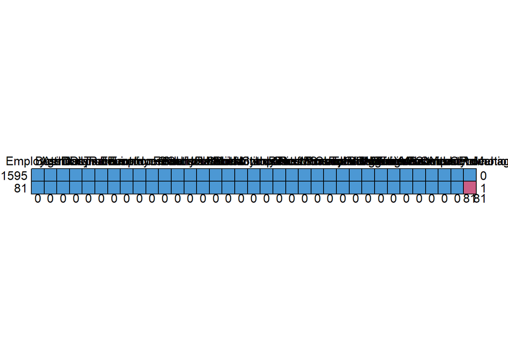

```
##      EmployeeID Age Attrition BusinessTravel DailyRate Department
## 1595          1   1         1              1         1          1
## 81            1   1         1              1         1          1
##               0   0         0              0         0          0
##      DistanceFromHome Education EducationField EmployeeCount
## 1595                1         1              1             1
## 81                  1         1              1             1
##                     0         0              0             0
##      EnvironmentSatisfaction Gender HourlyRate JobInvolvement JobRole
## 1595                       1      1          1              1       1
## 81                         1      1          1              1       1
##                            0      0          0              0       0
##      JobSatisfaction MaritalStatus MonthlyIncome MonthlyRate NumCompaniesWorked
## 1595               1             1             1           1                  1
## 81                 1             1             1           1                  1
```

[output cut: 17 more lines]

```r
if (!require(mice)) install.packages("mice")
library(mice)
md.pattern(att)
```

#### Descriptive Statistics of Dataset with Missing Values Included

```r
att.continuous <- att %>%
select(Age, DailyRate, DistanceFromHome, Education, HourlyRate, MonthlyIncome, MonthlyRate, NumCompaniesWorked, PercentSalaryHike, StandardHours, TotalWorkingYears, YearsAtCompany, YearsInCurrentRole,YearsSinceLastPromotion, YearsWithCurrManager)
summary(att.continuous)
```

```
##       Age          DailyRate      DistanceFromHome   Education
##  Min.   :18.00   Min.   : 102.0   Min.   : 1.000   Min.   :1.000
##  1st Qu.:30.00   1st Qu.: 465.0   1st Qu.: 2.000   1st Qu.:2.000
##  Median :36.00   Median : 796.5   Median : 7.000   Median :3.000
##  Mean   :36.87   Mean   : 800.6   Mean   : 9.222   Mean   :2.908
##  3rd Qu.:43.00   3rd Qu.:1157.0   3rd Qu.:14.000   3rd Qu.:4.000
##  Max.   :60.00   Max.   :1499.0   Max.   :29.000   Max.   :5.000
##    HourlyRate     MonthlyIncome    MonthlyRate    NumCompaniesWorked
##  Min.   : 30.00   Min.   : 1009   Min.   : 2094   Min.   :0.000
##  1st Qu.: 48.00   1st Qu.: 2928   1st Qu.: 7993   1st Qu.:1.000
##  Median : 65.50   Median : 4899   Median :14270   Median :2.000
##  Mean   : 65.47   Mean   : 6517   Mean   :14287   Mean   :2.662
##  3rd Qu.: 83.00   3rd Qu.: 8380   3rd Qu.:20462   3rd Qu.:4.000
##  Max.   :100.00   Max.   :19999   Max.   :26999   Max.   :9.000
##  PercentSalaryHike StandardHours TotalWorkingYears YearsAtCompany
##  Min.   :11.0      Min.   :80    Min.   : 0.00     Min.   : 0.000
##  1st Qu.:12.0      1st Qu.:80    1st Qu.: 6.00     1st Qu.: 3.000
##  Median :14.0      Median :80    Median :10.00     Median : 5.000
##  Mean   :15.2      Mean   :80    Mean   :11.34     Mean   : 7.033
##  3rd Qu.:18.0      3rd Qu.:80    3rd Qu.:15.00     3rd Qu.:10.000
##  Max.   :25.0      Max.   :80    Max.   :40.00     Max.   :40.000
##  YearsInCurrentRole YearsSinceLastPromotion YearsWithCurrManager
##  Min.   : 0.000     Min.   : 0.0            Min.   : 0.000
##  1st Qu.: 2.000     1st Qu.: 0.0            1st Qu.: 2.000
##  Median : 3.000     Median : 1.0            Median : 3.000
##  Mean   : 4.265     Mean   : 2.2            Mean   : 4.135
##  3rd Qu.: 7.000     3rd Qu.: 3.0            3rd Qu.: 7.000
##  Max.   :18.000     Max.   :15.0            Max.   :17.000
```

```r
att.nomord<-att%>%
  select(!c(EmployeeID, Age, DailyRate, DistanceFromHome, Education, HourlyRate, MonthlyIncome, MonthlyRate, NumCompaniesWorked, PercentSalaryHike, StandardHours, TotalWorkingYears, TrainingTimesLastYear, YearsAtCompany, YearsInCurrentRole,YearsSinceLastPromotion, YearsWithCurrManager))
summary(att.nomord)
```

```
##  Attrition            BusinessTravel      Department           EducationField
##  No :1477   Non-Travel       : 172   Cardiology:531   Human Resources : 29
##  Yes: 199   Travel_Rarely    :1184   Maternity :796   Life Sciences   :697
##             Travel_Frequently: 320   Neurology :349   Marketing       :189
##                                                       Medical         :524
##                                                       Other           : 88
##                                                       Technical Degree:149
##  EmployeeCount EnvironmentSatisfaction    Gender    JobInvolvement JobLevel
##  Min.   :1     1:330                   Female:678   1: 96          1   :621
##  1st Qu.:1     2:326                   Male  :998   2:433          2   :606
##  Median :1     3:512                                3:983          3   :246
##  Mean   :1     4:508                                4:164          4   :122
##  3rd Qu.:1                                                         NA's: 81
##  Max.   :1
##            JobRole    JobSatisfaction  MaritalStatus Over18   OverTime
##  Administrative:131   1:329           Divorced:377   Y:1676   No :1200
##  Nurse         :822   2:310           Married :777            Yes: 476
##  Other         :534   3:507           Single  :522
##  Therapist     :189   4:530
##
##
##  PerformanceRating RelationshipSatisfaction Shift   WorkLifeBalance
##  1:   0            1:310                    0:708   1:  90
##  2:   0            2:346                    1:684   2: 385
##  3:1424            3:526                    2:185   3:1028
##  4: 252            4:494                    3: 99   4: 173
##
##
```

#### Attrition by Job Level with NA Included

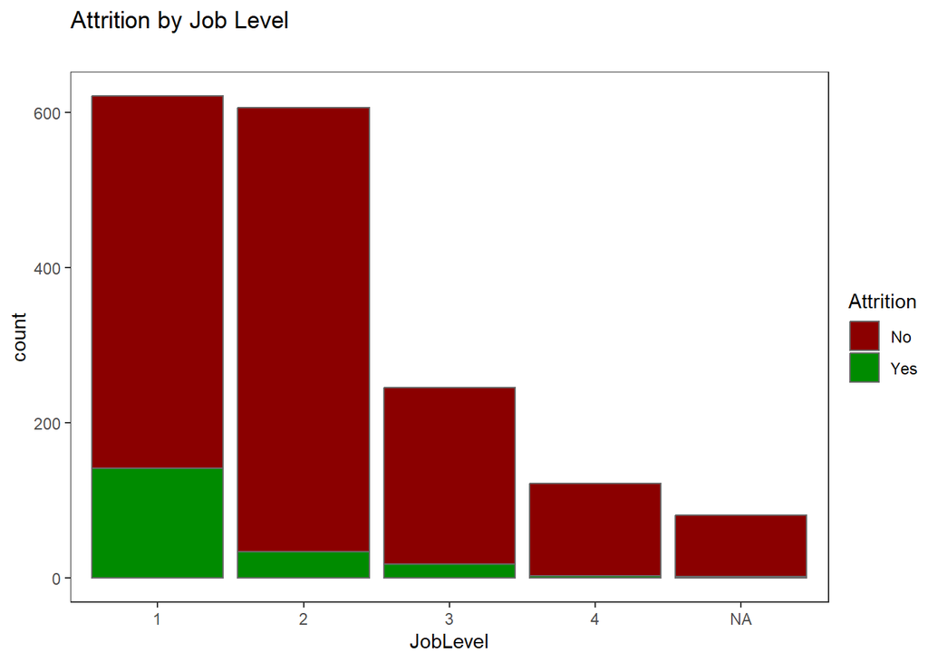

```r
ggplot(data = att, aes(x = JobLevel, fill = Attrition)) +
  geom_bar(color = "dimgrey") +
  theme_test() +
  scale_fill_manual(values = c("red4", "green4")) +
  labs(
    title = "Attrition by Job Level",
    subtitle = ""
  )
```

```r
addmargins(table(att$JobLevel,att$Attrition))
```

```
##
##         No  Yes  Sum
##   1    479  142  621
##   2    572   34  606
##   3    228   18  246
##   4    119    3  122
##   Sum 1398  197 1595
```

#### Descriptive Statistics of Dataset with Observations with Missing Values Removed

```r
att.na <- na.omit(att)
att.na.continuous <- att.na %>%
select(Age, DailyRate, DistanceFromHome, Education, HourlyRate, MonthlyIncome, MonthlyRate, NumCompaniesWorked, PercentSalaryHike, StandardHours, TotalWorkingYears, YearsAtCompany, YearsInCurrentRole,YearsSinceLastPromotion, YearsWithCurrManager)
summary(att.na.continuous)
```

```
##       Age          DailyRate      DistanceFromHome   Education
##  Min.   :18.00   Min.   : 102.0   Min.   : 1.000   Min.   :1.000
##  1st Qu.:30.00   1st Qu.: 465.0   1st Qu.: 2.000   1st Qu.:2.000
##  Median :35.00   Median : 796.0   Median : 7.000   Median :3.000
##  Mean   :36.31   Mean   : 799.6   Mean   : 9.389   Mean   :2.905
##  3rd Qu.:42.00   3rd Qu.:1154.0   3rd Qu.:15.000   3rd Qu.:4.000
##  Max.   :60.00   Max.   :1499.0   Max.   :29.000   Max.   :5.000
##    HourlyRate     MonthlyIncome    MonthlyRate    NumCompaniesWorked
##  Min.   : 30.00   Min.   : 1009   Min.   : 2094   Min.   :0.000
##  1st Qu.: 48.00   1st Qu.: 2860   1st Qu.: 7932   1st Qu.:1.000
##  Median : 66.00   Median : 4724   Median :14284   Median :1.000
##  Mean   : 65.44   Mean   : 5874   Mean   :14290   Mean   :2.622
##  3rd Qu.: 83.00   3rd Qu.: 7365   3rd Qu.:20469   3rd Qu.:4.000
##  Max.   :100.00   Max.   :17924   Max.   :26999   Max.   :9.000
##  PercentSalaryHike StandardHours TotalWorkingYears YearsAtCompany
##  Min.   :11.00     Min.   :80    Min.   : 0.00     Min.   : 0.000
##  1st Qu.:12.00     1st Qu.:80    1st Qu.: 6.00     1st Qu.: 3.000
##  Median :14.00     Median :80    Median : 9.00     Median : 5.000
##  Mean   :15.25     Mean   :80    Mean   :10.59     Mean   : 6.643
##  3rd Qu.:18.00     3rd Qu.:80    3rd Qu.:14.00     3rd Qu.: 9.000
##  Max.   :25.00     Max.   :80    Max.   :40.00     Max.   :40.000
##  YearsInCurrentRole YearsSinceLastPromotion YearsWithCurrManager
##  Min.   : 0.000     Min.   : 0.000          Min.   : 0.000
##  1st Qu.: 2.000     1st Qu.: 0.000          1st Qu.: 2.000
##  Median : 3.000     Median : 1.000          Median : 3.000
##  Mean   : 4.153     Mean   : 2.092          Mean   : 4.003
##  3rd Qu.: 7.000     3rd Qu.: 2.000          3rd Qu.: 7.000
##  Max.   :17.000     Max.   :15.000          Max.   :17.000
```

```r
att.na.nomord<-att.na%>%
  select(!c(EmployeeID, Age, DailyRate, DistanceFromHome, Education, HourlyRate, MonthlyIncome, MonthlyRate, NumCompaniesWorked, PercentSalaryHike, StandardHours, TotalWorkingYears, TrainingTimesLastYear, YearsAtCompany, YearsInCurrentRole,YearsSinceLastPromotion, YearsWithCurrManager))
summary(att.na.nomord)
```

```
##  Attrition            BusinessTravel      Department           EducationField
##  No :1398   Non-Travel       : 168   Cardiology:515   Human Resources : 24
##  Yes: 197   Travel_Rarely    :1119   Maternity :777   Life Sciences   :666
##             Travel_Frequently: 308   Neurology :303   Marketing       :180
##                                                       Medical         :495
##                                                       Other           : 84
##                                                       Technical Degree:146
##  EmployeeCount EnvironmentSatisfaction    Gender    JobInvolvement JobLevel
##  Min.   :1     1:313                   Female:649   1: 90          1:621
##  1st Qu.:1     2:311                   Male  :946   2:413          2:606
##  Median :1     3:492                                3:932          3:246
##  Mean   :1     4:479                                4:160          4:122
##  3rd Qu.:1
##  Max.   :1
##            JobRole    JobSatisfaction  MaritalStatus Over18   OverTime
##  Administrative: 83   1:316           Divorced:357   Y:1595   No :1140
##  Nurse         :822   2:293           Married :735            Yes: 455
##  Other         :506   3:476           Single  :503
##  Therapist     :184   4:510
##
##
##  PerformanceRating RelationshipSatisfaction Shift   WorkLifeBalance
##  1:   0            1:298                    0:678   1: 89
##  2:   0            2:332                    1:639   2:367
##  3:1351            3:499                    2:181   3:975
##  4: 244            4:466                    3: 97   4:164
##
##
```

```r
att<-att.na
```

## Descriptive Statistics and Visualizations

### Descriptive Statistics

**Continuous Variables**

```r
att.continuous <- att %>%
select(Age, Attrition, DailyRate, DistanceFromHome, HourlyRate, MonthlyIncome, MonthlyRate, NumCompaniesWorked, PercentSalaryHike, TotalWorkingYears, YearsAtCompany, YearsInCurrentRole,YearsSinceLastPromotion, YearsWithCurrManager)
att.continuous %>%
  select(!Attrition) %>%
  tbl_summary(
    statistic = list(
      all_continuous() ~ "{mean} ({sd})")
    )
```

| **Characteristic** | **N = 1,595**<sup>1</sup> |
| --- | --- |
| Age | 36 (9) |
| DailyRate | 800 (401) |
| DistanceFromHome | 9 (8) |
| HourlyRate | 65 (20) |
| MonthlyIncome | 5,874 (3,866) |
| MonthlyRate | 14,290 (7,153) |
| NumCompaniesWorked | 3 (2) |
| PercentSalaryHike | 15 (4) |
| TotalWorkingYears | 11 (7) |
| YearsAtCompany | 7 (6) |
| YearsInCurrentRole | 4 (3) |
| YearsSinceLastPromotion | 2 (3) |
| YearsWithCurrManager | 4 (3) |

<sup>1</sup> Mean (SD)

```r
att.continuous %>%
  tbl_summary(
    by = Attrition,
    statistic = list(
      all_continuous() ~ "{mean} ({sd})")
  ) %>% add_p()
```

| **Characteristic** | **No**, N = 1,398<sup>1</sup> | **Yes**, N = 197<sup>1</sup> | **p-value**<sup>2</sup> |
| --- | --- | --- | --- |
| Age | 37 (9) | 31 (9) | <0.001 |
| DailyRate | 807 (402) | 744 (394) | 0.034 |
| DistanceFromHome | 9 (8) | 12 (9) | <0.001 |
| HourlyRate | 66 (20) | 64 (19) | 0.2 |
| MonthlyIncome | 6,157 (3,925) | 3,867 (2,675) | <0.001 |
| MonthlyRate | 14,177 (7,131) | 15,092 (7,272) | 0.10 |
| NumCompaniesWorked | 3 (2) | 3 (3) | >0.9 |
| PercentSalaryHike | 15 (4) | 15 (4) | 0.7 |
| TotalWorkingYears | 11 (7) | 6 (5) | <0.001 |
| YearsAtCompany | 7 (6) | 4 (4) | <0.001 |
| YearsInCurrentRole | 4 (4) | 2 (2) | <0.001 |
| YearsSinceLastPromotion | 2 (3) | 1 (2) | <0.001 |
| YearsWithCurrManager | 4 (3) | 2 (3) | <0.001 |

<sup>1</sup> Mean (SD)  
<sup>2</sup> Wilcoxon rank sum test

**Nominal and Ordinal Variables**

```r
att.nomord<-att%>%
  select(!c(EmployeeID, Age, DailyRate, DistanceFromHome, HourlyRate, MonthlyIncome, MonthlyRate, NumCompaniesWorked, PercentSalaryHike, StandardHours, TotalWorkingYears, TrainingTimesLastYear, YearsAtCompany, YearsInCurrentRole,YearsSinceLastPromotion, YearsWithCurrManager))
tbl_summary(att.nomord)
```

| **Characteristic** | **N = 1,595**<sup>1</sup> |
| --- | --- |
| Attrition | 197 (12%) |
| BusinessTravel |  |
| Non-Travel | 168 (11%) |
| Travel_Rarely | 1,119 (70%) |
| Travel_Frequently | 308 (19%) |
| Department |  |
| Cardiology | 515 (32%) |
| Maternity | 777 (49%) |
| Neurology | 303 (19%) |
| Education |  |
| 1 | 189 (12%) |
| 2 | 306 (19%) |
| 3 | 622 (39%) |
| 4 | 424 (27%) |
| 5 | 54 (3.4%) |
| EducationField |  |
| Human Resources | 24 (1.5%) |
| Life Sciences | 666 (42%) |
| Marketing | 180 (11%) |
| Medical | 495 (31%) |
| Other | 84 (5.3%) |
| Technical Degree | 146 (9.2%) |
| EmployeeCount | 1,595 (100%) |
| EnvironmentSatisfaction |  |
| 1 | 313 (20%) |
| 2 | 311 (19%) |
| 3 | 492 (31%) |
| 4 | 479 (30%) |
| Gender |  |
| Female | 649 (41%) |
| Male | 946 (59%) |
| JobInvolvement |  |
| 1 | 90 (5.6%) |
| 2 | 413 (26%) |
| 3 | 932 (58%) |
| 4 | 160 (10%) |
| JobLevel |  |
| 1 | 621 (39%) |
| 2 | 606 (38%) |
| 3 | 246 (15%) |
| 4 | 122 (7.6%) |
| JobRole |  |
| Administrative | 83 (5.2%) |
| Nurse | 822 (52%) |
| Other | 506 (32%) |
| Therapist | 184 (12%) |
| JobSatisfaction |  |
| 1 | 316 (20%) |
| 2 | 293 (18%) |
| 3 | 476 (30%) |
| 4 | 510 (32%) |
| MaritalStatus |  |
| Divorced | 357 (22%) |
| Married | 735 (46%) |
| Single | 503 (32%) |
| Over18 |  |
| Y | 1,595 (100%) |
| OverTime | 455 (29%) |
| PerformanceRating |  |
| 1 | 0 (0%) |
| 2 | 0 (0%) |
| 3 | 1,351 (85%) |
| 4 | 244 (15%) |
| RelationshipSatisfaction |  |
| 1 | 298 (19%) |
| 2 | 332 (21%) |
| 3 | 499 (31%) |
| 4 | 466 (29%) |
| Shift |  |
| 0 | 678 (43%) |
| 1 | 639 (40%) |
| 2 | 181 (11%) |
| 3 | 97 (6.1%) |
| WorkLifeBalance |  |
| 1 | 89 (5.6%) |
| 2 | 367 (23%) |
| 3 | 975 (61%) |
| 4 | 164 (10%) |

<sup>1</sup> n (%)

```r
att.nomord %>%
  tbl_summary(
    by = Attrition
  )
```

| **Characteristic** | **No**, N = 1,398<sup>1</sup> | **Yes**, N = 197<sup>1</sup> |
| --- | --- | --- |
| BusinessTravel |  |  |
| Non-Travel | 152 (11%) | 16 (8.1%) |
| Travel_Rarely | 995 (71%) | 124 (63%) |
| Travel_Frequently | 251 (18%) | 57 (29%) |
| Department |  |  |
| Cardiology | 441 (32%) | 74 (38%) |
| Maternity | 680 (49%) | 97 (49%) |
| Neurology | 277 (20%) | 26 (13%) |
| Education |  |  |
| 1 | 162 (12%) | 27 (14%) |
| 2 | 271 (19%) | 35 (18%) |
| 3 | 534 (38%) | 88 (45%) |
| 4 | 378 (27%) | 46 (23%) |
| 5 | 53 (3.8%) | 1 (0.5%) |
| EducationField |  |  |
| Human Resources | 18 (1.3%) | 6 (3.0%) |
| Life Sciences | 583 (42%) | 83 (42%) |
| Marketing | 152 (11%) | 28 (14%) |
| Medical | 445 (32%) | 50 (25%) |
| Other | 76 (5.4%) | 8 (4.1%) |
| Technical Degree | 124 (8.9%) | 22 (11%) |
| EmployeeCount | 1,398 (100%) | 197 (100%) |
| EnvironmentSatisfaction |  |  |
| 1 | 249 (18%) | 64 (32%) |
| 2 | 273 (20%) | 38 (19%) |
| 3 | 444 (32%) | 48 (24%) |
| 4 | 432 (31%) | 47 (24%) |
| Gender |  |  |
| Female | 563 (40%) | 86 (44%) |
| Male | 835 (60%) | 111 (56%) |
| JobInvolvement |  |  |
| 1 | 61 (4.4%) | 29 (15%) |
| 2 | 342 (24%) | 71 (36%) |
| 3 | 845 (60%) | 87 (44%) |
| 4 | 150 (11%) | 10 (5.1%) |
| JobLevel |  |  |
| 1 | 479 (34%) | 142 (72%) |
| 2 | 572 (41%) | 34 (17%) |
| 3 | 228 (16%) | 18 (9.1%) |
| 4 | 119 (8.5%) | 3 (1.5%) |
| JobRole |  |  |
| Administrative | 83 (5.9%) | 0 (0%) |
| Nurse | 715 (51%) | 107 (54%) |
| Other | 420 (30%) | 86 (44%) |
| Therapist | 180 (13%) | 4 (2.0%) |
| JobSatisfaction |  |  |
| 1 | 265 (19%) | 51 (26%) |
| 2 | 252 (18%) | 41 (21%) |
| 3 | 416 (30%) | 60 (30%) |
| 4 | 465 (33%) | 45 (23%) |
| MaritalStatus |  |  |
| Divorced | 333 (24%) | 24 (12%) |
| Married | 675 (48%) | 60 (30%) |
| Single | 390 (28%) | 113 (57%) |
| Over18 |  |  |
| Y | 1,398 (100%) | 197 (100%) |
| OverTime | 318 (23%) | 137 (70%) |
| PerformanceRating |  |  |
| 1 | 0 (0%) | 0 (0%) |
| 2 | 0 (0%) | 0 (0%) |
| 3 | 1,186 (85%) | 165 (84%) |
| 4 | 212 (15%) | 32 (16%) |
| RelationshipSatisfaction |  |  |
| 1 | 258 (18%) | 40 (20%) |
| 2 | 292 (21%) | 40 (20%) |
| 3 | 432 (31%) | 67 (34%) |
| 4 | 416 (30%) | 50 (25%) |
| Shift |  |  |
| 0 | 539 (39%) | 139 (71%) |
| 1 | 598 (43%) | 41 (21%) |
| 2 | 175 (13%) | 6 (3.0%) |
| 3 | 86 (6.2%) | 11 (5.6%) |
| WorkLifeBalance |  |  |
| 1 | 65 (4.6%) | 24 (12%) |
| 2 | 313 (22%) | 54 (27%) |
| 3 | 877 (63%) | 98 (50%) |
| 4 | 143 (10%) | 21 (11%) |

<sup>1</sup> n (%)

### Demographics

**Please see each visualization’s subtitle for takeaway messages**

#### Age, All Roles

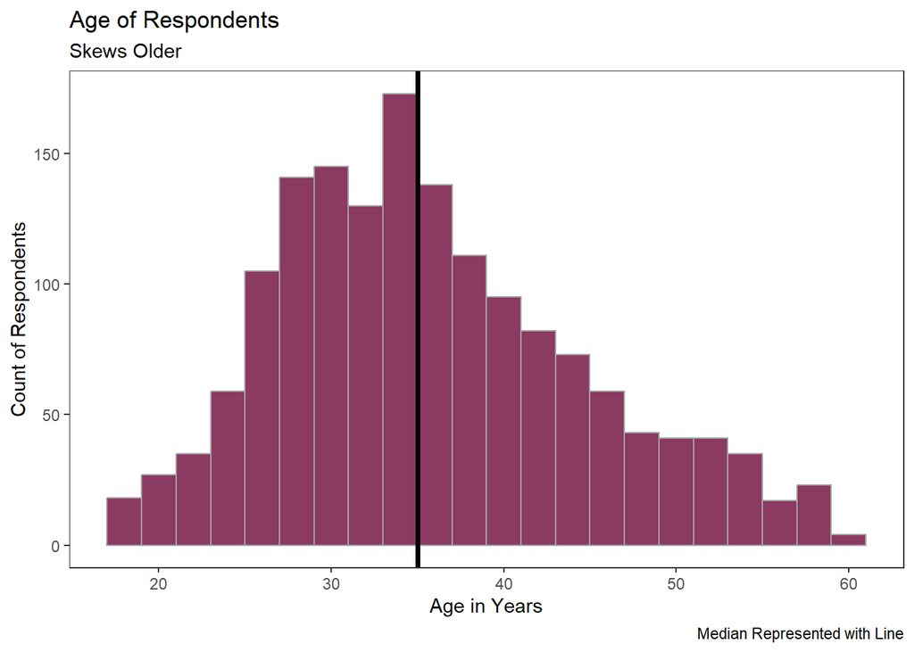

```r
ggplot(data = att, aes(Age)) +
  geom_histogram(binwidth = 2, color = "grey65",fill = "hotpink4") +
  geom_vline(aes(xintercept = median(Age)), color = "black", linewidth = 1.25) +
  theme_test()+
  labs(
    title = "Age of Respondents",
    subtitle = "Skews Older",
    x = "Age in Years",
    y = "Count of Respondents",
    caption = "Median Represented with Line"
  )
```

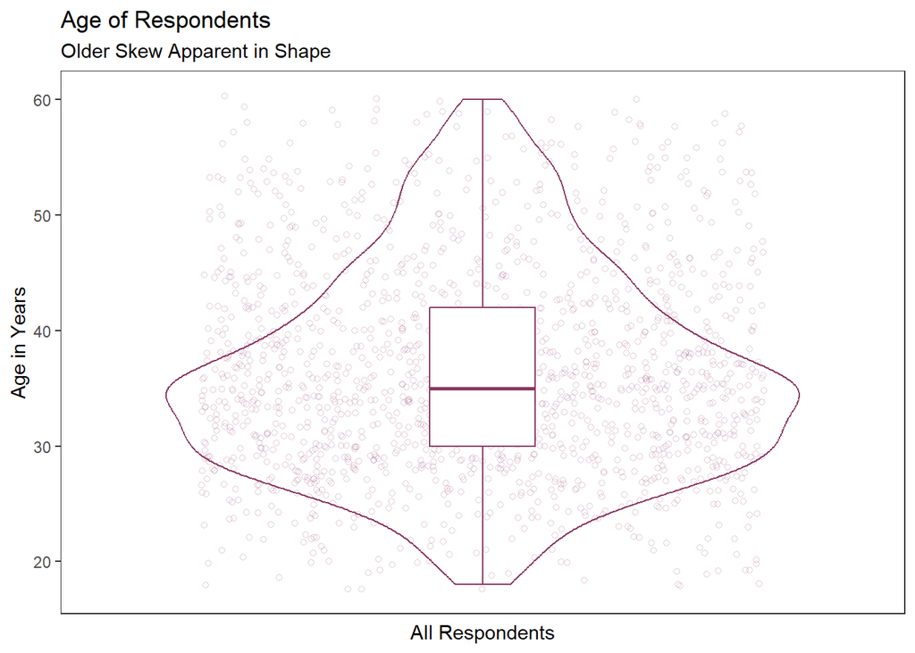

```r
ggplot(data = att, aes(x = "", y=Age)) +
  geom_violin(color = "hotpink4") +
  geom_jitter(shape = 21, alpha = 0.25, color = "hotpink4") +
  theme_test() +
  theme(
    axis.ticks.x = element_blank(),
    axis.text.x = element_blank()
  ) +
  geom_boxplot(width = 0.15, color = "hotpink4", show.legend = FALSE) +
  labs(
    title = "Age of Respondents",
    subtitle = "Older Skew Apparent in Shape",
    x = "All Respondents",
    y = "Age in Years"
  )
```

#### Job Role

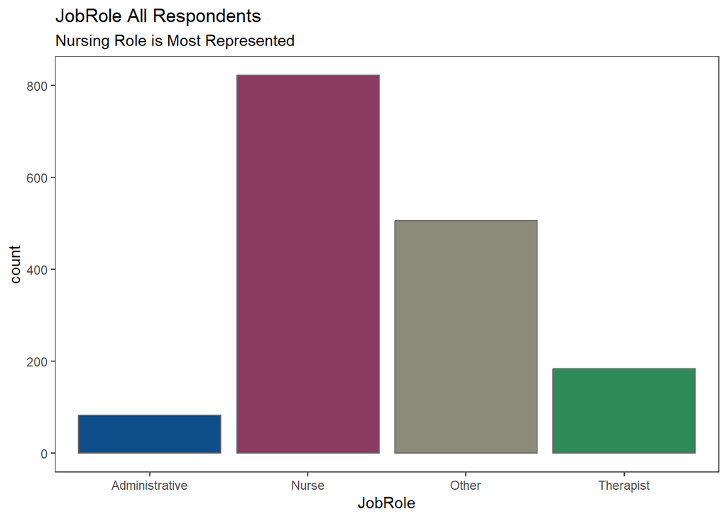

```r
ggplot(data = att, aes(x = JobRole, fill = JobRole)) +
  geom_bar(color = "dimgrey", show.legend = FALSE) +
  theme_test() +
  scale_fill_manual(values = c("dodgerblue4", "hotpink4", "lightyellow4", "seagreen4")) +
  labs(
    title = "JobRole All Respondents",
    subtitle = "Nursing Role is Most Represented"
  )
```

#### Age by Job Role

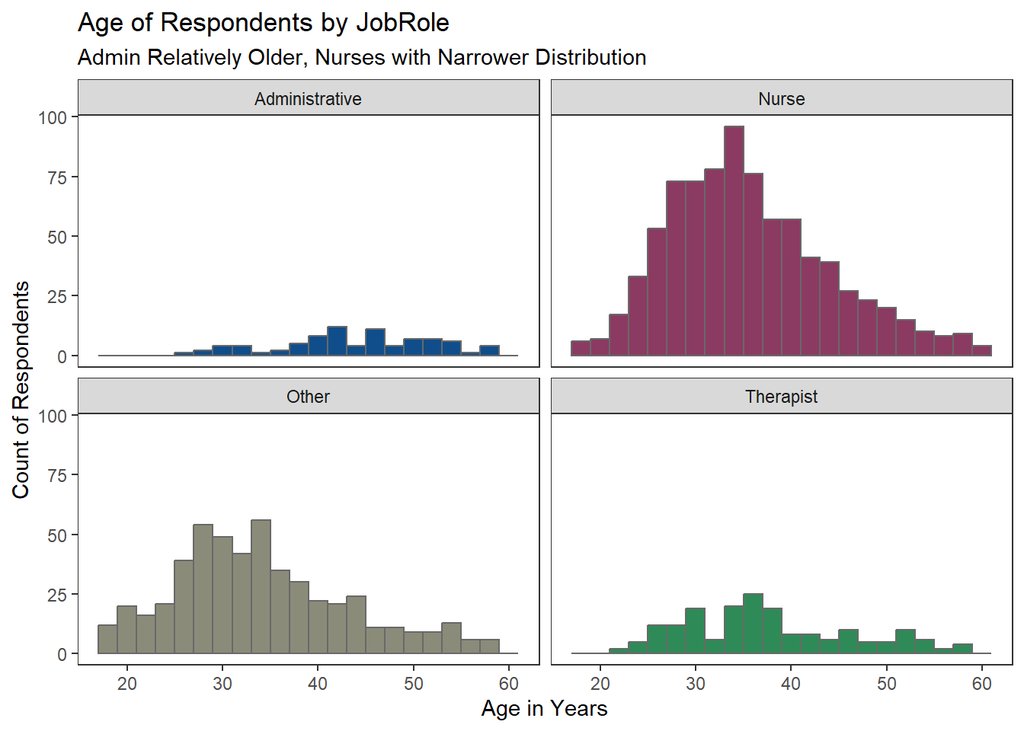

```r
ggplot(data = att, aes(Age, fill = JobRole)) +
  geom_histogram(binwidth = 2, color = "dimgrey", show.legend = FALSE) +
  facet_wrap(~att$JobRole) +
  theme_test()+
  scale_fill_manual(values = c("dodgerblue4", "hotpink4", "lightyellow4", "seagreen4")) +
  labs(
    title = "Age of Respondents by JobRole",
    subtitle = "Admin Relatively Older, Nurses with Narrower Distribution",
    x = "Age in Years",
    y = "Count of Respondents"
  )
```

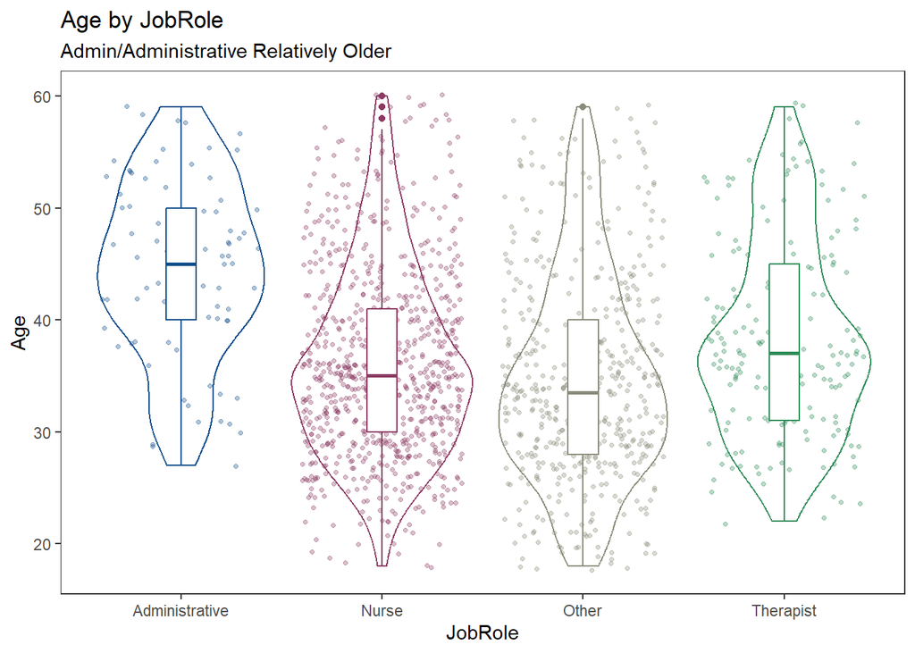

```r
ggplot(data = att, aes(x = JobRole, y = Age, color = JobRole)) +
  geom_violin(show.legend = FALSE) +
  geom_jitter(show.legend = FALSE, shape = 20, alpha = 0.33) +
  theme_test() +
  geom_boxplot(width = 0.15, show.legend = FALSE) +
  labs(
    title = "Age by JobRole",
    subtitle = "Admin/Administrative Relatively Older"
  ) +
  scale_color_manual(values = c("dodgerblue4", "hotpink4", "lightyellow4", "seagreen4"))
```

#### Gender

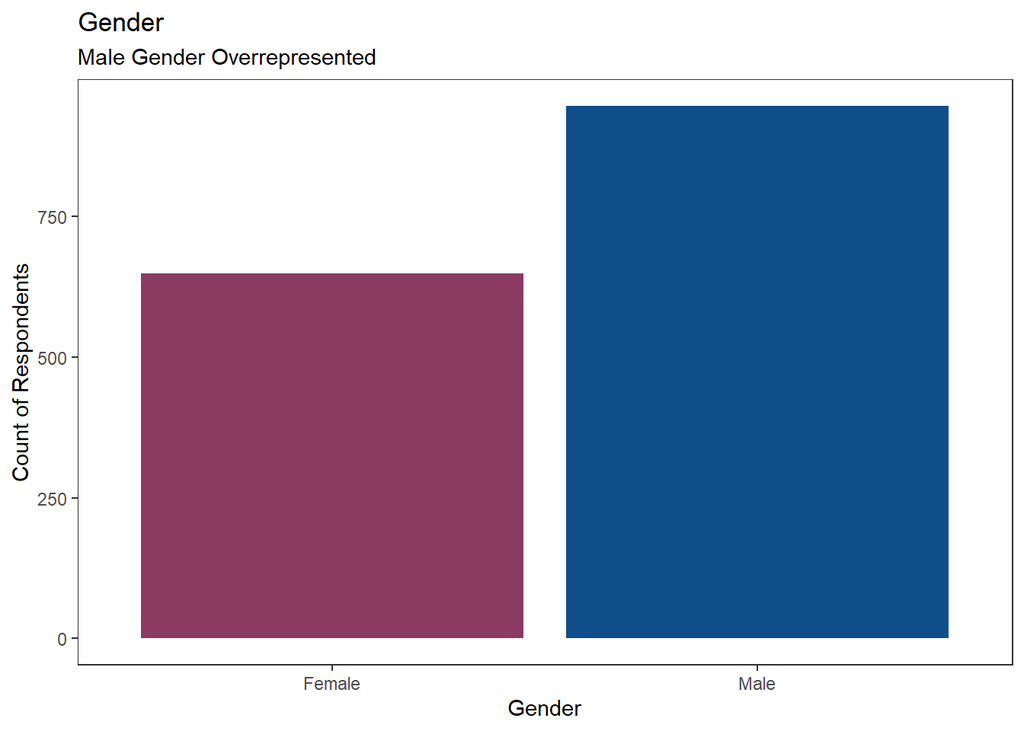

```r
ggplot(data = att, aes(x = Gender, fill = Gender)) +
  geom_bar(show.legend = FALSE) +
  scale_fill_manual(values = c("hotpink4", "dodgerblue4")) +
  theme_test() +
  labs(
    title = "Gender",
    subtitle = "Male Gender Overrepresented",
    y = "Count of Respondents"
  )
```

#### Gender by Job Role

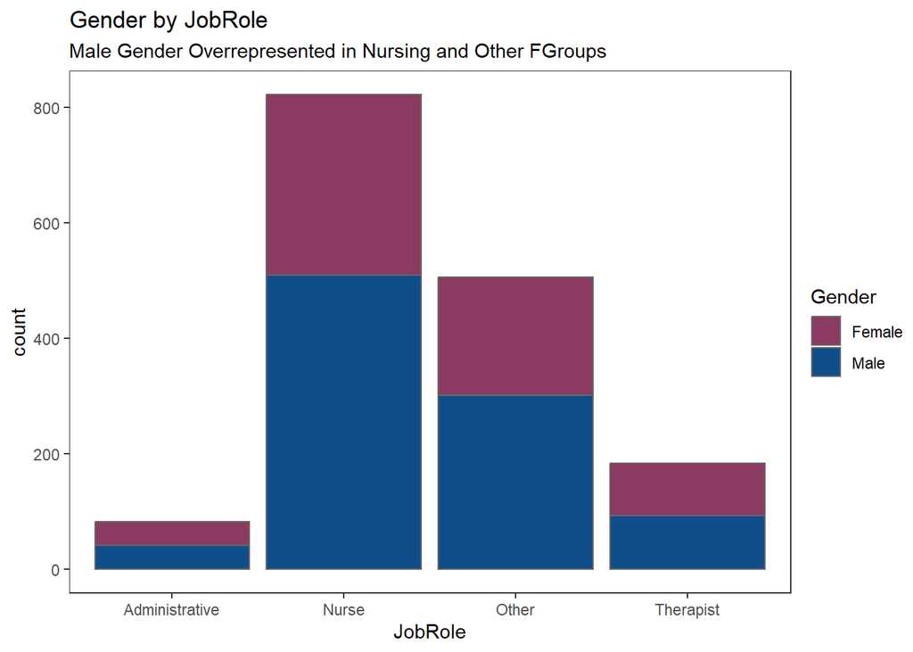

```r
ggplot(data = att, aes(x = JobRole, fill = Gender)) +
  geom_bar(color = "dimgrey") +
  theme_test() +
  scale_fill_manual(values = c("hotpink4", "dodgerblue4")) +
  labs(
    title = "Gender by JobRole",
    subtitle = "Male Gender Overrepresented in Nursing and Other FGroups"
  )
```

#### Marital Status

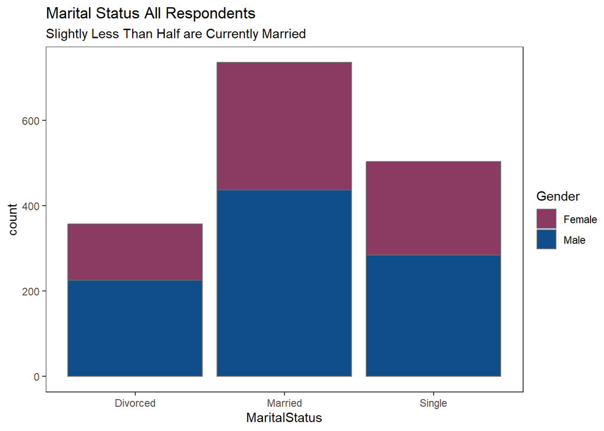

```r
ggplot(data = att, aes(x = MaritalStatus, fill = Gender)) +
  geom_bar(color = "dimgrey") +
  theme_test() +
  labs(
    title = "Marital Status All Respondents",
    subtitle = "Slightly Less Than Half are Currently Married"
  ) +
  scale_fill_manual(values = c("hotpink4", "dodgerblue4"))
```

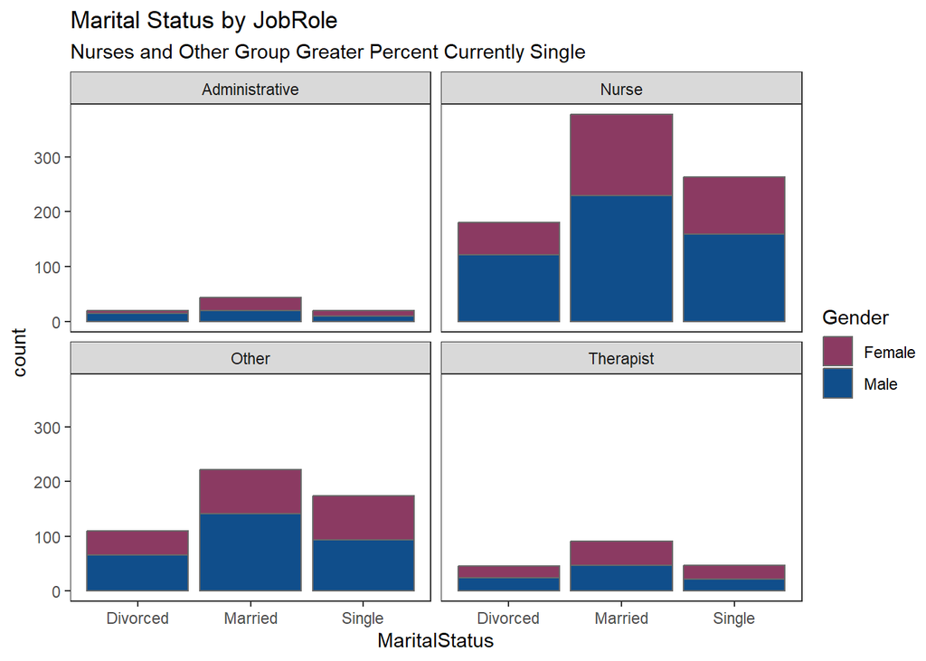

```r
ggplot(data = att, aes(x = MaritalStatus, fill = Gender)) +
  geom_bar(color = "dimgrey") +
  theme_test() +
  facet_wrap(~JobRole) +
  scale_fill_manual(values = c("hotpink4", "dodgerblue4")) +
  labs(
    title = "Marital Status by JobRole",
    subtitle = "Nurses and Other Group Greater Percent Currently Single"
  )
```